# Homework 2 - R GGPLOT2

Reid Otsuji & Tim Dennis

1/19/2018

## Due 1/25 - By Midnight

### How to submit your homework:

1. Download the r-homework2.Rmd Rmarkdown file and open in Rstudio
2. Rename `r-homework2.Rmd` to `yourlastname_sudentID_r-homework2.Rmd`
3. Type the R code answers in the code chunks.
4. Save the Rmarkdown file.
5. Submit your assignment by uploading the file to TritonEd for assignment 2.

**Remeber to load the ggplot2 package and read in gapminder data**

```r
#setwd('~/workshops/lecture-notes/gps-skills-2017/homework/')
gapminder <- read.csv('data/gapminder-FiveYearData.csv')
library(ggplot2)
```

**Each questions worth 10 points – 50 points total**

### Question 1. Adding text to the graph

The following code produces multiple panels of life expectancy over time from `gapminder` focusing only on those countries with names that start with the letter “A” or “Z”.

We start by subsetting the data. We use the substr function to pull out a part of a character string; in this case, the letters that occur in positions start through stop, inclusive, of the `gapminder$country` vector. The operator `%in%` allows us to make multiple comparisons rather than write out long subsetting conditions (in this case, `starts.with %in% c("A", "Z")` is equivalent to `starts.with == "A" | starts.with == "Z"`). Run the code in the code chunk to get a feel for the steps involved.

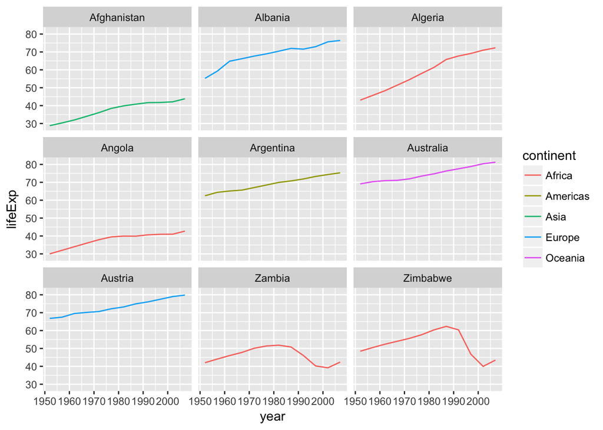

```r
# Run this chunk to see the example plot
starts.with <- substr(gapminder$country, start = 1, stop = 1)
az.countries <- gapminder[starts.with %in% c("A", "Z"), ]
ggplot(data = az.countries, aes(x = year, y = lifeExp, color=continent)) +
  geom_line() + facet_wrap( ~ country)
```

To clean this figure up for a publication we need to change some of the text elements. The x-axis is too cluttered, and the y axis should read “Life expectancy”, rather than the column name in the data frame.

We can do this by adding a couple of different layers. The theme layer controls the axis text, and overall text size. Labels for the axes, plot title and any legend can be set using the labs function. Legend titles are set using the same names we used in the aes specification. The color legend title is set using color = “Continent”,

Set the title to “Figure 1”, X label to “Year”, Y Label to “Life Expectancy”, and Legend title to “Continent”. Use the lab and theme functions to set those.

YOUR ANSWER:

```r
starts.with <- substr(gapminder$country, start = 1, stop = 1)
az.countries <- gapminder[starts.with %in% c("A", "Z"), ]

# complete the ggplot labs and theme functions
ggplot(data = az.countries, aes(x = year, y = lifeExp, color=continent)) +
  geom_line() + facet_wrap( ~ country) +
  labs() + theme()
```

YOUR ANSWER:

## Question 2. Basic scatter plot

Use the **mtcars** dataset available in RStudio (look at the help: `?mtcars`). The data was extracted from the 1974 Motor Trend US magazine, and comprises fuel consumption and 10 aspects of automobile design and performance for 32 automobiles (1973–74 models). Create a scatter plot that shows the relationship between various car weights (wt), miles per gallon (mpg) and engine cylinders (cyl). Use colored points to show the different cylinders in the plot. Note: you will need to convert cyl to a factor. You will need the function `factor()` to do this.

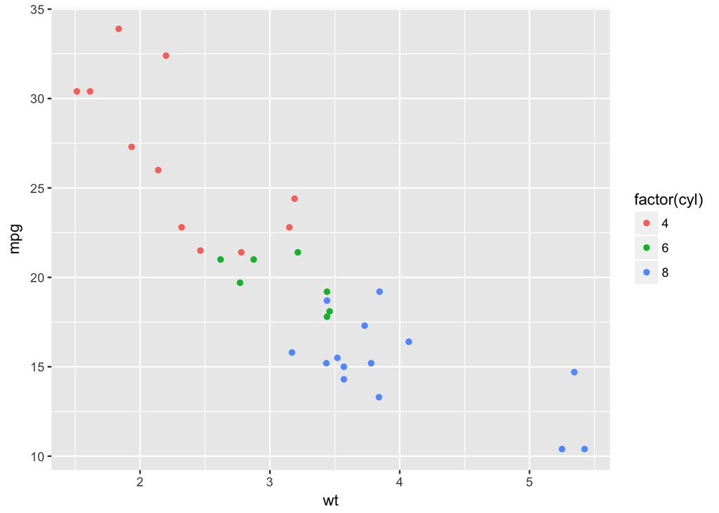

YOUR ANSWER:

## Question 3. Adding shapes

Using the solution from the previous example, create a new plot using shapes to differentiate the various engine cylinders.

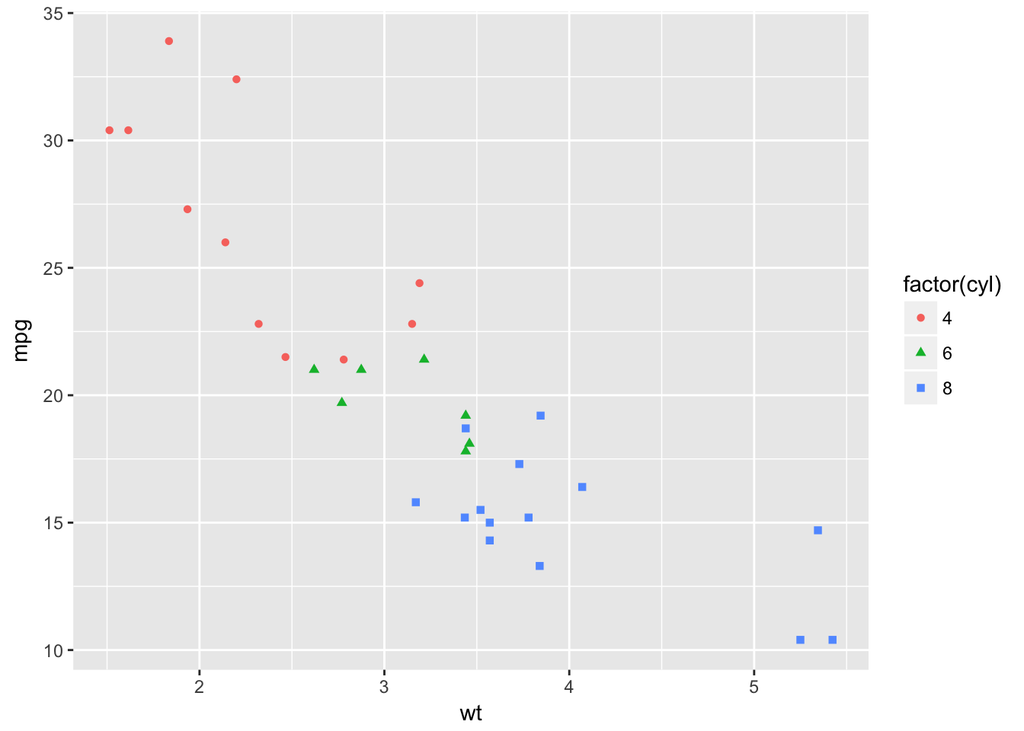

YOUR ANSWER:

## Question 4. Assign a ggplot function to an object.

Create a ggplot function that contains the built-in `diamonds` dataset and an aesthetics layer. Map `carat` on the x axis and `price` on the y axis. Assign the ggplot function to an object: **myplot**

Using **+** , add a `geom_point` with an alpha of 0.1. Then add (`+`) geom_smooth and `theme_minimal` layers to the `myplot` object. Map **clarity** to the color argument in the `geom_smooth` function (add **se=FALSE** to `geom_smooth` to turn off error shading).

Note: the plot will take a few seconds to generate.

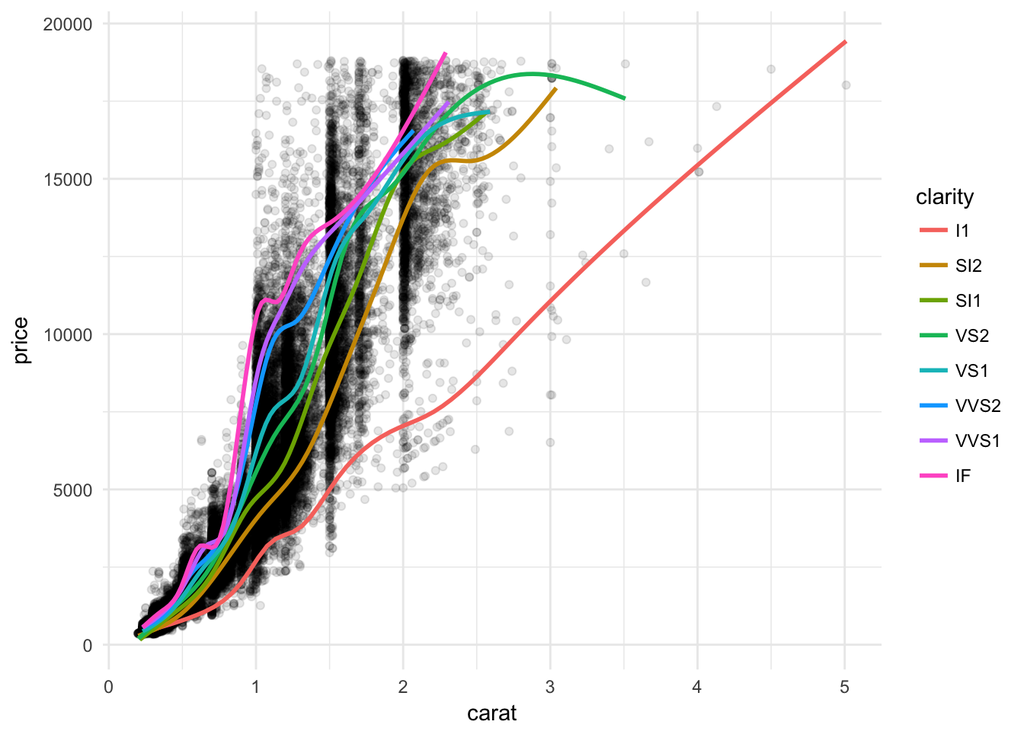

YOUR ANSWER:

## Question 5. Creating an area graph

Using the gapminder data we used on Wed.’s class, create a density plot of GDP per capita, filled by continent that looks like the following: NOTE: Transform the x axis using a log10 to better visualise the data spread. - Add a facet layer to panel the density plots by year.

Hint: Look up the `facet_wrap` and `scale_x_*` functions to help you accomplish this.

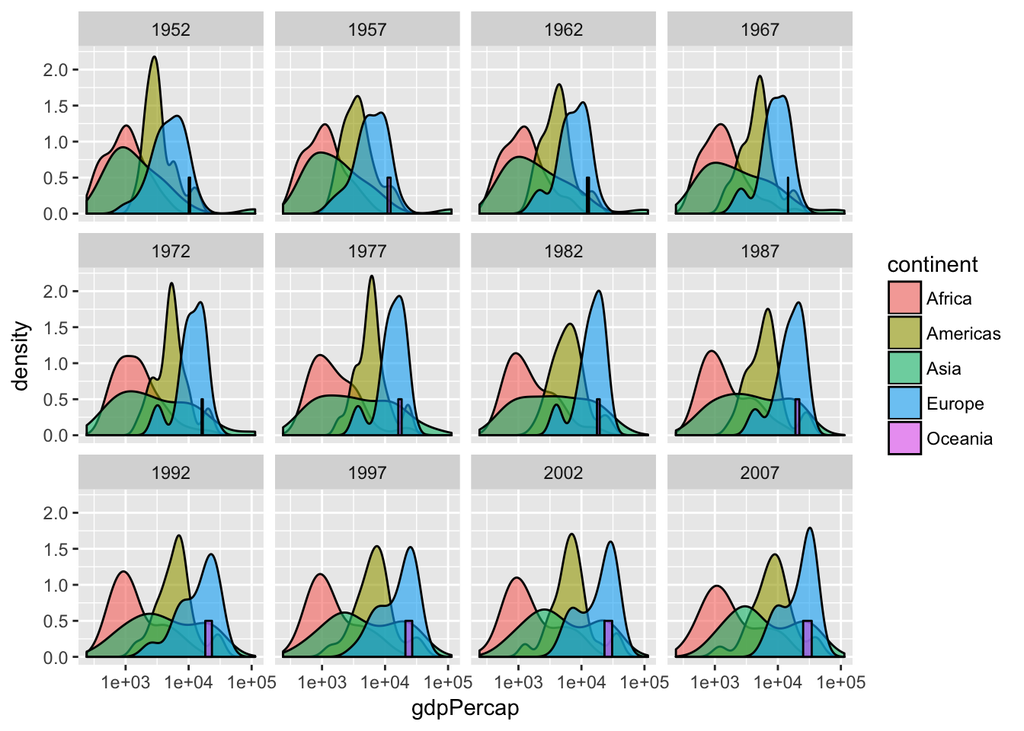

YOUR ANSWER: